# Code de base pour le calcul du Laplacien

# Comparaison avec spot au milieu et ensuite on bouche le spot et on ouvre les côtés

Ouverture au milieu

```python
N=5 # Nombre de ligne
M=200 # Nombre de colonne
V=np.zeros([N+1,M+1]) #Initialisation du réseau.
#V[1:99,1:99]=0.25*(V[2:100,1:99]+V[0:98,1:99]+V[1:99,2:100]+V[1:99,0:98])
#V[1:N-1,1:N-1]=0.25*(V[2:N,1:N-1]+V[0:N-2,1:N-1]+V[1:N-1,2:N]+V[1:N-1,0:N-2])

ParMaille=1#(N/M)**2
Eps= 1e-10
Ecart=1.0
i=np.arange(1,8)
Size=np.zeros(len(i))
Field=np.zeros(len(i))
while Ecart>Eps:
    Vprec=V.copy()
    V[N,:]=100 # Toutes les colonnes, et la ligne 99
    V[:,0]=V[:,1] #Bord Gauche
    V[:,M]=V[:,M-1] #Bord Droit

    V[1:N,1:M]=(1/(2*(ParMaille+1)))*(ParMaille*(V[2:N+1,1:M]+V[0:N-1,1:M])+V[1:N,2:M+1]+V[1:N,0:M-1])

    V[0,0:70]= V[1,0:70]
    V[0,130:M]= V[1,130:M]
    Ecart = np.max(np.abs(V-Vprec))
```

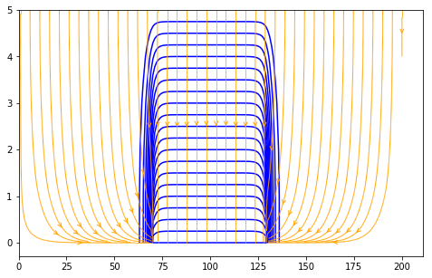

```python
x = np.arange(0,M+1,1)
y = np.arange(0,N+1,1)
X,Y = np.meshgrid(x,y)

A=np.linspace(1,M,40)
B = (N-1)*np.ones(len(A))
seed_points = np.array([A,B])


Ey,Ex = np.gradient(V)

Ey=-Ey
Ex=-Ex
plt.figure(figsize=(8,5))
plt.contour(X,Y,V,20,colors='b')
plt.streamplot(X, Y, Ex, Ey,linewidth=1,arrowstyle='->',density=10,start_points=seed_points.T,color='orange')
```

```python
100/np.sum(Ey[0,:])
```

```
-0.034774321199684884
```

Ouverture sur les côtés

```python
N=5 # Nombre de ligne
M=200 # Nombre de colonne
V=np.zeros([N+1,M+1]) #Initialisation du réseau.
#V[1:99,1:99]=0.25*(V[2:100,1:99]+V[0:98,1:99]+V[1:99,2:100]+V[1:99,0:98])
#V[1:N-1,1:N-1]=0.25*(V[2:N,1:N-1]+V[0:N-2,1:N-1]+V[1:N-1,2:N]+V[1:N-1,0:N-2])

ParMaille=1#(N/M)**2
Eps= 1e-10
Ecart=1.0
i=np.arange(1,8)
Size=np.zeros(len(i))
Field=np.zeros(len(i))
while Ecart>Eps:
    Vprec=V.copy()
    V[N,:]=100 # Toutes les colonnes, et la ligne 99
    V[:,0]=V[:,1] #Bord Gauche
    V[:,M]=V[:,M-1] #Bord Droit

    V[1:N,1:M]=(1/(2*(ParMaille+1)))*(ParMaille*(V[2:N+1,1:M]+V[0:N-1,1:M])+V[1:N,2:M+1]+V[1:N,0:M-1])

    V[0,70:130]= V[1,70:130]
    Ecart = np.max(np.abs(V-Vprec))
```

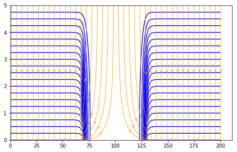

```python
x = np.arange(0,M+1,1)
y = np.arange(0,N+1,1)
X,Y = np.meshgrid(x,y)

A=np.linspace(1,M,40)
B = (N-1)*np.ones(len(A))
seed_points = np.array([A,B])


Ey,Ex = np.gradient(V)

Ey=-Ey
Ex=-Ex
plt.figure(figsize=(8,5))
plt.contour(X,Y,V,20,colors='b')
plt.streamplot(X, Y, Ex, Ey,linewidth=1,arrowstyle='->',density=10,start_points=seed_points.T,color='orange')
```

```python
1000/np.sum(Ey[0,:])
```

```
-0.3477432119968489
```

# Essai spot avec épaisseur

```python
N=60 # Nombre de ligne
M=200 # Nombre de colonne
V=np.zeros([N+1,M+1]) #Initialisation du réseau.
#V[1:99,1:99]=0.25*(V[2:100,1:99]+V[0:98,1:99]+V[1:99,2:100]+V[1:99,0:98])
#V[1:N-1,1:N-1]=0.25*(V[2:N,1:N-1]+V[0:N-2,1:N-1]+V[1:N-1,2:N]+V[1:N-1,0:N-2])

ParMaille=1#(N/M)**2
Eps= 1e-10
Ecart=1.0
i=np.arange(1,8)
Size=np.zeros(len(i))
Field=np.zeros(len(i))
while Ecart>Eps:
    Vprec=V.copy()
    V[N,:]=100 # Toutes les colonnes, et la ligne 99
    V[:,0]=V[:,1] #Bord Gauche
    V[:,M]=V[:,M-1] #Bord Droit

    V[1:N,1:M]=(1/(2*(ParMaille+1)))*(ParMaille*(V[2:N+1,1:M]+V[0:N-1,1:M])+V[1:N,2:M+1]+V[1:N,0:M-1])

    V[int(N/2)-1,0:70]= V[int(N/2)-2,0:70]
    V[int(N/2)-1,130:M]= V[int(N/2)-2,130:M]
    V[int(N/2)+1,0:70]= V[int(N/2)+2,0:70]
    V[int(N/2)+1,130:M]= V[int(N/2)+2,130:M]

    Ecart = np.max(np.abs(V-Vprec))
```

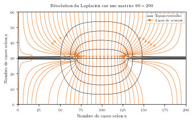

```python
x = np.arange(0,M+1,1)
y = np.arange(0,N+1,1)
X,Y = np.meshgrid(x,y)

A=np.linspace(1,M,40)
B = (N-1)*np.ones(len(A))
seed_points = np.array([A,B])


Ey,Ex = np.gradient(V)

Ey=-Ey
Ex=-Ex



plt.rc('text', usetex=True)
plt.rc('font', family='serif')
#1 inch equals to 2.54 cm
fig=plt.figure(figsize=(15/2.54,(9/16)*(15/2.54)))

plt.streamplot(X, Y, Ex, Ey,linewidth=0.75,arrowstyle='->',density=10,start_points=seed_points.T,color="#ef6700")

equ=plt.contour(X,Y,V,10,linewidths=0.6,linestyles="-",colors="k")
#plt.clabel(equ, fontsize=7, inline=10,inline_spacing=10,fmt='%1.0f'+" V")

plt.plot([0],[0],label="Equipotentielles",linestyle='-',linewidth=0.9,color="k")
plt.plot([0],[0],label="Ligne de courant",linestyle='-',marker=">",markersize=4,linewidth=0.9,color="#ef6700")
plt.xlabel(r"Nombre de cases selon x",fontsize = 9)
plt.ylabel(r"Nombre de cases selon y",fontsize = 9)
plt.title(r"Résolution du Laplacien sur une matrice $60 \times 200$ ",fontsize = 9,pad=10)
plt.rc('xtick', labelsize=7)
plt.rc('ytick', labelsize=7)
plt.legend(prop={'size': 6})
```

```python
np.sum(Ey[40])
```

```
-180.9072178421798
```

## Essai avec matrice sur différents endroits

```python
N=80 # Nombre de ligne
M=200 # Nombre de colonne
B=int(N/2)-2 #Limite inférieur de la zone délimité 38
A=int(N/2)+2 #Limite inférieur de la zone délimité 42

V=np.zeros([N+1,M+1]) #Initialisation du réseau.
#V[1:99,1:99]=0.25*(V[2:100,1:99]+V[0:98,1:99]+V[1:99,2:100]+V[1:99,0:98])
#V[1:N-1,1:N-1]=0.25*(V[2:N,1:N-1]+V[0:N-2,1:N-1]+V[1:N-1,2:N]+V[1:N-1,0:N-2])

ParMaille=1#(N/M)**2
Eps= 1e-10
Ecart=1.0
i=np.arange(1,8)
Size=np.zeros(len(i))
Field=np.zeros(len(i))
while Ecart>Eps:
    Vprec=V.copy()
    V[N,:]=100 # Toutes les colonnes, et la ligne 99
    V[:,0]=V[:,1] #Bord Gauche
    V[:,M]=V[:,M-1] #Bord Droit

    V[A:N,1:M]=(1/(2*(ParMaille+1)))*(ParMaille*(V[A+1:N+1,1:M]+V[A-1:N-1,1:M])+V[A:N,2:M+1]+V[A:N,0:M-1])
    V[1:B+1,1:M]=(1/(2*(ParMaille+1)))*(ParMaille*(V[2:B+2,1:M]+V[0:B,1:M])+V[1:B+1,2:M+1]+V[1:B+1,0:M-1])
    V[B:A,70:130]=(1/(2*(ParMaille+1)))*(ParMaille*(V[B+1:A+1,70:130]+V[B-1:A-1,70:130])+V[B:A,71:131]+V[B:A,69:129])

    #V1
    V[B+1,0:70]= V[B,0:70]
    V[B+1,130:M]= V[B,130:M]

    #V2
    V[A-1,0:70]= V[A,0:70]
    V[A-1,130:M]= V[A,130:M]

    Ecart = np.max(np.abs(V-Vprec))
V[B:A-1,0:70]=0
V[B:A-1,130:M]=0
```

```python
np.sum(Ey[40,70:130])
```

```
-125.33764669909198
```

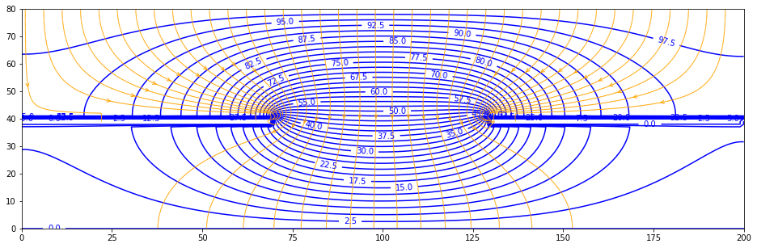

```python
x = np.arange(0,M+1,1)
y = np.arange(0,N+1,1)
X,Y = np.meshgrid(x,y)

A=np.linspace(1,M,40)
B = (N-1)*np.ones(len(A))
seed_points = np.array([A,B])


Ey,Ex = np.gradient(V)

Ey=-Ey
Ex=-Ex
plt.figure(figsize=(16,5))
equ=plt.contour(X,Y,V,40,colors='b')
plt.clabel(equ, fontsize=10, inline=1,fmt='%0.01f')
plt.streamplot(X, Y, Ex, Ey,linewidth=1,arrowstyle='->',density=10,start_points=seed_points.T,color='orange')
```

```python
np.sum(Ey[80,:])
```

```
-128.75148197277142
```

## Décomposition en deux surfaces

Dans cette partie on a pris deux surfaces sur lesquelles on a calculé : dans lapremière la solution de l'equation avec solution initial et ensuite dans la deuxième on reprend la dernière ligne de la premiere et on la copie sur la première de la deuxième. On finit par coller les deux courbes.

```python
from copy import deepcopy
```

```python
N=50 # Nombre de ligne
M=200 # Nombre de colonne
V=np.zeros([N+1,M+1]) #Initialisation du réseau.

#V[1:99,1:99]=0.25*(V[2:100,1:99]+V[0:98,1:99]+V[1:99,2:100]+V[1:99,0:98])
#V[1:N-1,1:N-1]=0.25*(V[2:N,1:N-1]+V[0:N-2,1:N-1]+V[1:N-1,2:N]+V[1:N-1,0:N-2])

ParMaille=1#(N/M)**2
Eps= 1e-10
Ecart=1.0
i=np.arange(1,8)
Size=np.zeros(len(i))
Field=np.zeros(len(i))
while Ecart>Eps:
    Vprec=V.copy()
    V[N,:]=100 # Toutes les colonnes, et la ligne 99
    #Neumann sur les bords gauche et droite
    V[0,70:130]=50
    V[0:N,0]=V[0:N,1]
    V[0:N,M]=V[0:N,M-1]

    #Neumann à droite et à gauche du spot

    V[0,0:70]=V[1,0:70]
    V[0,130:M]=V[1,130:M]

    V[1:N,1:M]=(1/(2*(ParMaille+1)))*(ParMaille*(V[2:N+1,1:M]+V[0:N-1,1:M])+ V[1:N,2:M+1]+V[1:N,0:M-1])

    #Conditions sur le spot

    Ecart = np.max(np.abs(V-Vprec))
```

```python
N2=50
M=200
V2=np.zeros([N2+1,M+1])

ParMaille=1#(N/M)**2
Eps= 1e-10
Ecart=1.0
i=np.arange(1,8)
Size=np.zeros(len(i))
Field=np.zeros(len(i))
V2[N2,70:130]=V[0,70:130] # Toutes les colonnes, et la ligne 99
while Ecart>Eps:
    V2prec=V2.copy()
    #Neumann sur les bords gauche et droite
    V2[0:N2,0]=V2[0:N2,1]
    V2[0:N2,M]=V2[0:N2,M-1]

    #Neumann à droite et à gauche du spot

    V2[N2,0:70]=V2[N2-1,0:70]
    V2[N2,130:M]=V2[N2-1,130:M]

    V2[1:N2,1:M]=(1/(2*(ParMaille+1)))*(ParMaille*(V2[2:N2+1,1:M]+V2[0:N2-1,1:M])+ V2[1:N2,2:M+1]+V2[1:N2,0:M-1])

    #Conditions sur le spot

    Ecart = np.max(np.abs(V2-V2prec))
```

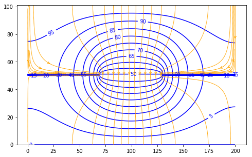

```python
%matplotlib inline
V1=V
Ey1,Ex1 = np.gradient(V1)

Ey1=Ey1
Ex1=Ex1

Ey2,Ex2 = np.gradient(V2)

Ey2=Ey2
Ex2=Ex2
Ey=-np.vstack((Ey2,Ey1))
Ex=-np.vstack((Ex2,Ex1))

Vf=np.vstack((V2,V1))
x = np.arange(0,M+1,1)
y = np.arange(0,N+N2+2,1)
X,Y = np.meshgrid(x,y)

A=np.linspace(1,M,40)
B = (52)*np.ones(len(A))
seed_points = np.array([A,B])
plt.figure(figsize=(8,5))
equ=plt.contour(X,Y,Vf,20,colors='b')
plt.clabel(equ, fontsize=10, inline=1,fmt='%1.0f')
plt.streamplot(X, Y, Ex, Ey,linewidth=1,arrowstyle='->',density=10,start_points=seed_points.T,color='orange')
```

```python
np.sum(Ey[0,:])
```

```
-101.23651477101328
```

[output not shown]

[figure not shown]

```python
V=np.delete(V,0,axis=0)
#V2=np.delete(V2,N2,axis=0)
Vf=np.vstack((V2,V))
x = np.arange(0,M+1,1)
y = np.arange(0,N+N2+1,1)
X,Y = np.meshgrid(x,y)

A=np.linspace(1,M,40)
B = (N-1)*np.ones(len(A))
seed_points = np.array([A,B])


Ey,Ex = np.gradient(Vf)

Ey=-Ey
Ex=-Ex
plt.figure(figsize=(8,5))
plt.contour(X,Y,Vf,20,colors='b')
plt.streamplot(X, Y, Ex, Ey,linewidth=1,arrowstyle='->',density=10,start_points=seed_points.T,color='orange')
```

```python
fig.savefig('C:/Users/antoi/Documents/Stage_IKOS/Memoire/img/holm_matlab_eq_2part.png')
```

[output not shown]

```python
np.sum(Ey [100,:])
```

```
-101.23631489476406
```

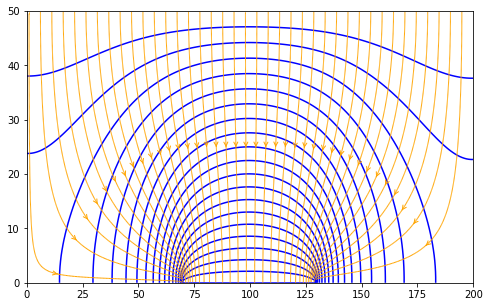

```python
x = np.arange(0,M+1,1)
y = np.arange(0,N+1,1)
X,Y = np.meshgrid(x,y)

A=np.linspace(1,M,40)
B = (N-1)*np.ones(len(A))
seed_points = np.array([A,B])


Ey,Ex = np.gradient(V)

Ey=-Ey
Ex=-Ex
plt.figure(figsize=(8,5))
plt.contour(X,Y,V,20,colors='b')
plt.streamplot(X, Y, Ex, Ey,linewidth=1,arrowstyle='->',density=10,start_points=seed_points.T,color='orange')
```

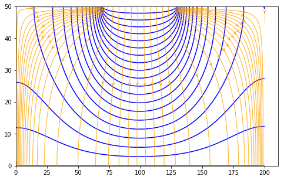

```python
N=50
x = np.arange(0,M+1,1)
y = np.arange(0,N+1,1)
X,Y = np.meshgrid(x,y)

A=np.linspace(1,M,40)
B = 45*np.ones(len(A))
seed_points = np.array([A,B])


Ey,Ex = np.gradient(V2)

Ey=-Ey
Ex=-Ex
plt.figure(figsize=(8,5))
plt.contour(X,Y,V2,20,colors='b')
plt.streamplot(X, Y, Ex, Ey,linewidth=1,arrowstyle='->',density=10,start_points=seed_points.T,color='orange')
```

```python
np.sum(Ey[0,:])
```

```
-101.23651477101328
```

# Spots en série (Ne marche pas)

```python
N=5 # Nombre de ligne
M=120 # Nombre de colonne
V=np.zeros([N+1,M+1]) #Initialisation du réseau.
#V[1:99,1:99]=0.25*(V[2:100,1:99]+V[0:98,1:99]+V[1:99,2:100]+V[1:99,0:98])
#V[1:N-1,1:N-1]=0.25*(V[2:N,1:N-1]+V[0:N-2,1:N-1]+V[1:N-1,2:N]+V[1:N-1,0:N-2])
Scale=19
ParMaille=1#(N/M)**2
Eps= 1e-10
Ecart=1.0
i=np.arange(1,8)
Size=np.zeros(len(i))
Field=np.zeros(len(i))
while Ecart>Eps:
    Vprec=V.copy()
    V[N,:]=100 # Toutes les colonnes, et la ligne 99
    V[:,0]=V[:,1] #Bord Gauche
    V[:,M]=V[:,M-1] #Bord Droit



    V[1:N,1:M]=(1/(2*(ParMaille+1)))*(ParMaille*(V[2:N+1,1:M]+V[0:N-1,1:M])+V[1:N,2:M+1]+V[1:N,0:M-1])


    #Première constriction
    V[0,0:50]= V[1,0:50]
    V[0,70:120]= V[1,70:120]
    V[0,0:50]= V[3,0:50]
    V[0,70:120]= V[3,70:120]
    V[0:2,50]=V[0:2,0] #Bord Gauche
    V[0:2,70]=V[0:2,120] #Bord Droit
    Ecart = np.max(np.abs(V-Vprec))
```

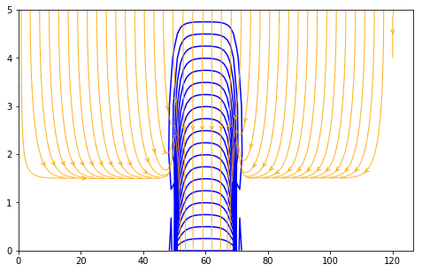

```python
x = np.arange(0,M+1,1)
y = np.arange(0,N+1,1)
X,Y = np.meshgrid(x,y)

A=np.linspace(1,M,40)
B = (N-1)*np.ones(len(A))
seed_points = np.array([A,B])


Ey,Ex = np.gradient(V)

Ey=-Ey
Ex=-Ex
plt.figure(figsize=(8,5))
plt.contour(X,Y,V,20,colors='b')
plt.streamplot(X, Y, Ex, Ey,linewidth=1,arrowstyle='->',density=10,start_points=seed_points.T,color='orange')
```

```python
Ey[0,0:49]
```

```
array([ 1.79963422e-09,  1.78098958e-09,  2.06276241e-09,  2.68222777e-09,
        3.76199694e-09,  5.51594326e-09,  8.29149371e-09,  1.26383526e-08,
        1.94175414e-08,  2.99717300e-08,  4.63913352e-08,  7.19284827e-08,
        1.11641185e-07,  1.73395009e-07,  2.69421136e-07,  4.18738722e-07,
        6.50922075e-07,  1.01195795e-06,  1.57335401e-06,  2.44630172e-06,
        3.80369926e-06,  5.91439583e-06,  9.19644094e-06,  1.42998841e-05,
        2.22355247e-05,  3.45751137e-05,  5.37626573e-05,  8.35984814e-05,
        1.29991928e-04,  2.02131759e-04,  3.14306058e-04,  4.88732010e-04,
        7.59955806e-04,  1.18169337e-03,  1.83746430e-03,  2.85711725e-03,
        4.44249316e-03,  6.90722244e-03,  1.07382499e-02,  1.66903121e-02,
        2.59288417e-02,  4.02385640e-02,  6.23008837e-02,  9.59602788e-02,
        1.46047836e-01,  2.15946326e-01,  2.95736567e-01,  3.13083882e-01,
       -6.14503519e-02])
```

# Supprimer les bords (Pas fructueux)

```python
#x = np.arange(0,N-1,1)
#y = np.arange(0,N-1,1)
#X,Y = np.meshgrid(x,y)

#V=np.delete(V, 0, axis=0)
#V=np.delete(V, N-1, axis=0)
#V=np.delete(V, 0, axis=1)
#V=np.delete(V, N-1, axis=1)

#A=np.linspace(0,98,40)
#B = 75*np.ones(len(A))
#seed_points = np.array([A,B])


#Ey,Ex = np.gradient(V)

#Ey=-Ey
#Ex=-Ex
#plt.figure(figsize=(8,5))
#plt.contour(X,Y,V,20,colors='b')
#plt.streamplot(X, Y, Ex, Ey,linewidth=1,arrowstyle='->',density=10,start_points=seed_points.T,color='orange')
```